# Questioning the influence of roots: A soil fauna perspective on rhizosphere space

## Executive Summary

This study investigates the spatial behavior of soil fauna in relation to root systems, challenging the notion of the rhizosphere as a simple, static attraction zone. By integrating null model simulations with Generalized Additive Models (GAMs), we decouple biological selection from physical habitat constraints and reveal that the demographic benefits of rhizosphere exploitation are governed by a distinct temporal lag.

## Setup and data preparation

## 1. The rhizosphere effect: attraction and spatial signature

### *Do soil fauna actively select the rhizosphere space ?*

We employ a null model approach to determine whether soil fauna actively select the rhizosphere or if their proximity is a result of random distribution. By comparing observed animal-to-root distances against simulated expected distances, we calculate a standardized Z-score ($Z = \frac{obs - exp}{sd}$).

- Active selection (attraction): Indicated by negative Z-scores.
- Active avoidance (aepulsion): Indicated by positive Z-scores.
- Statistical Validation: A Wilcoxon Test was used to determine if median Z-scores significantly deviated from zero.

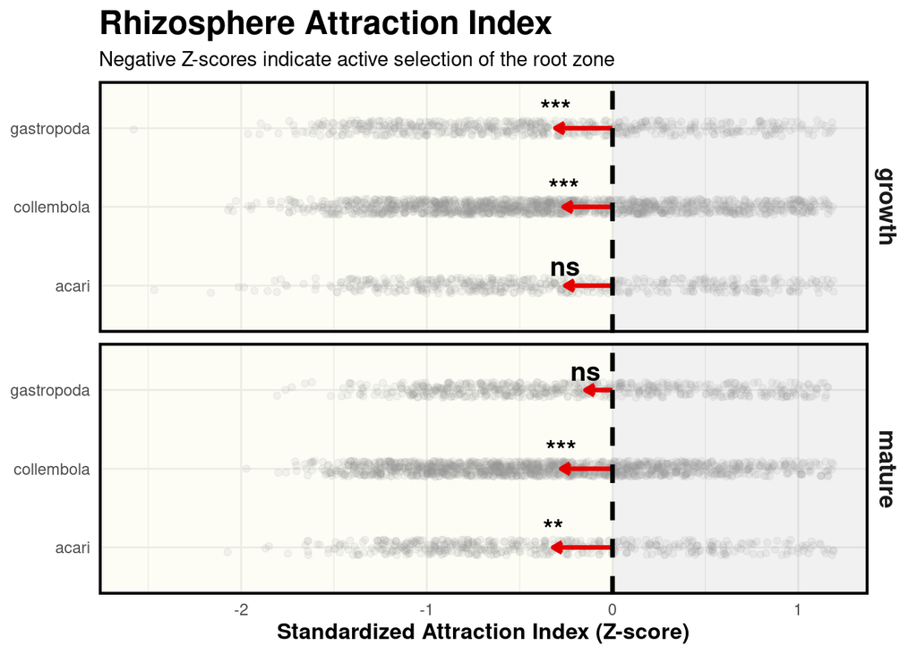

The analysis reveals significant, taxa-specific attraction to the root surface, particularly for Collembola and Gastropoda. The strength of this selection varies by root type, suggesting that biological drivers—such as root exudation—shape spatial clustering beyond what is expected by chance.

### *Defining the rhizosphere influence zone*

To identify the precise spatial extent of root influence, we model animal density as a function of distance using GAMs. We incorporate a geometric correction (log-area offset) to account for the increasing soil volume available at greater distances from the root. The RIZ tipping point is defined as the distance where the first derivative of the model plateau, indicating that the root’s influence on animal density has vanished.

Identification of the Rhizosphere Influence Zone (RIZ) through derivative analysis of animal density gradients

| taxa | root Type | complexity (EDF) | p-value | dev. Expl (%) | RIZ (cm) | n total |
| --- | --- | --- | --- | --- | --- | --- |
| acari | growth | 3.193 | 0 | 89.699 | NA | 448 |
|  | mature | 3.743 | 0 | 93.706 | 7.30 | 523 |
| collembola | growth | 3.792 | 0 | 94.624 | 8.20 | 1400 |
|  | mature | 3.895 | 0 | 96.765 | 8.20 | 1485 |
| gastropoda | growth | 3.630 | 0 | 88.473 | 7.75 | 597 |
|  | mature | 3.553 | 0 | 96.529 | 8.30 | 630 |

## 2. The geometric niche: habitat availability constraint

### *Are fauna close to the root by choice (attraction) or necessity (habitat saturation) ?*

While attraction is a key driver, the physical presence of roots inherently constrains the available habitat. As root density increases, bulk soil volume diminishes, mathematically increasing the probability of fauna-root encounters regardless of biological preference. To isolate the true “biological signal,” we modeled the deviation between observed and expected distances ($Obs - Exp$) across a root density gradient. We utilized a Generalized Additive Model (GAM) with a Student-t (scat) distribution to account for the heavy-tailed nature of ecological distance data.

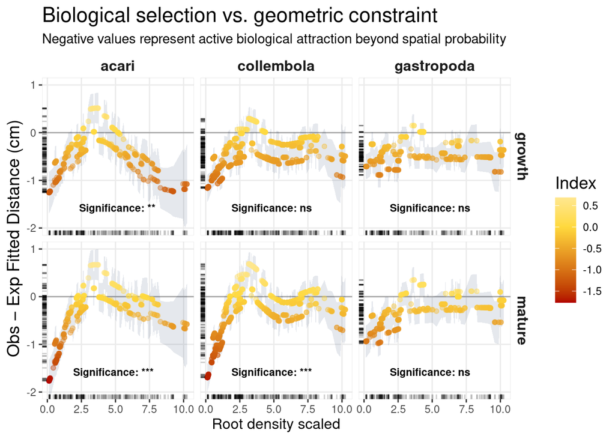

Mature Roots: These systems exhibit a “convergence” effect where biological deviation tends toward zero at high densities. This indicates that in dense mature networks, fauna proximity is increasingly governed by habitat availability constraints rather than active selection.

## 3. The selection - demography link : trait or by-product ?

### *Is root selection a mechanical consequence of high population density or a functional driver of invertebrate success ?*

We tested two competing hypotheses to explain the relationship between spatial behavior and population dynamics: a mechanistic approach, which tests whether demographic processes dictate spatial behavior, and a functional approach, which tests whether the ability to locate and exploit roots leads to population growth.

#### **1. Mechanistic hypothesis: Do demographic processes dictate spatial behaviour?**

*“The intensity of root selection is a behavioural response constrained by population density (density dependence).”*

Model :

`gam(delta.resid ~ Predicted.class.levelup + root_type + s(abundance, by = interaction(Predicted.class.levelup, root_type, drop=TRUE), k=10) + s(scanner, bs="re")+ s(period, bs="re"),family = gaussian(link = "identity"), method = "REML", select = TRUE, data = data_growth)`

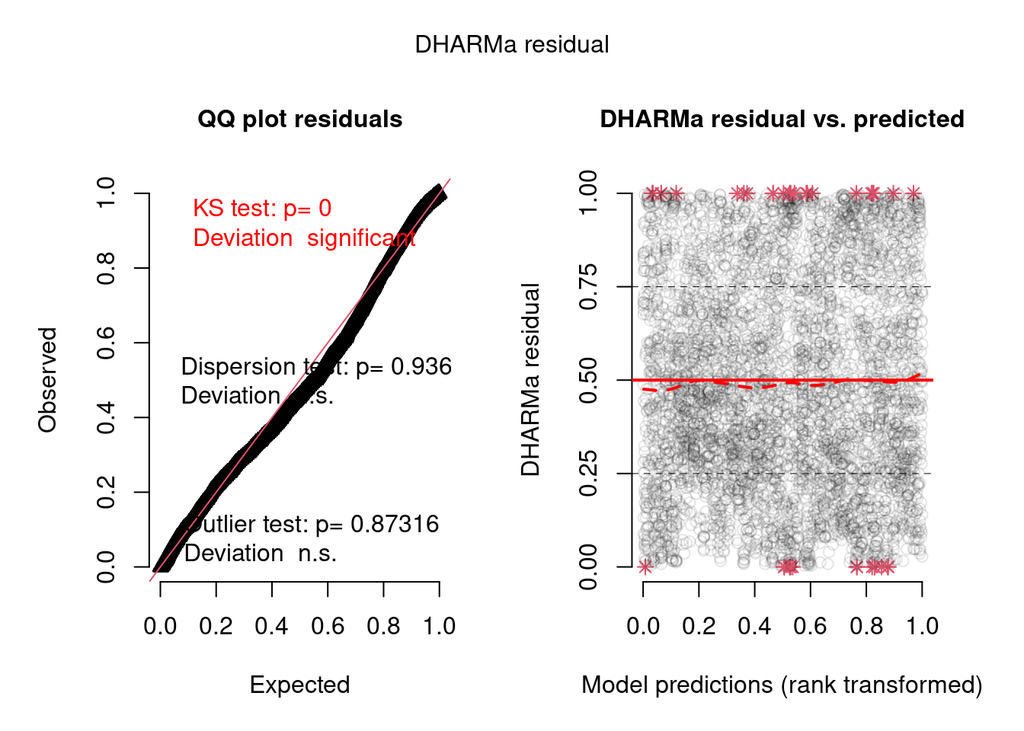

```
# A tibble: 3 × 3
  term                                                               edf p.value
  <chr>                                                            <dbl>   <dbl>
1 s(abundance):interaction(Predicted.class.levelup, root_type, dr…  3.26 5.66e-4
2 s(abundance):interaction(Predicted.class.levelup, root_type, dr…  1.52 8.33e-3
3 s(abundance):interaction(Predicted.class.levelup, root_type, dr…  3.66 1.17e-3
```

#### **2. Functional approach : Does an organism’s ability to locate and exploit the root result in an increase in its population?**

*As an “oasis” of resources (exudates, associated microflora, moisture), the root is not just a place where they happen to be, but a driver of their population dynamics. If a taxon is able to effectively ‘select’ roots (for mucus, exudates or microhabitats), it gains access to more energy, which promotes its reproduction and therefore its overall abundance.*

Model :

`gam(abundance ~ Predicted.class.levelup + root_type + s(delta.resid, by = interaction(Predicted.class.levelup, root_type, drop = TRUE), k=10) + s(scanner, bs="re")+ s(period, bs="re"), Gamma(link = "log"), data = data_growth,method = "REML", select = TRUE)`

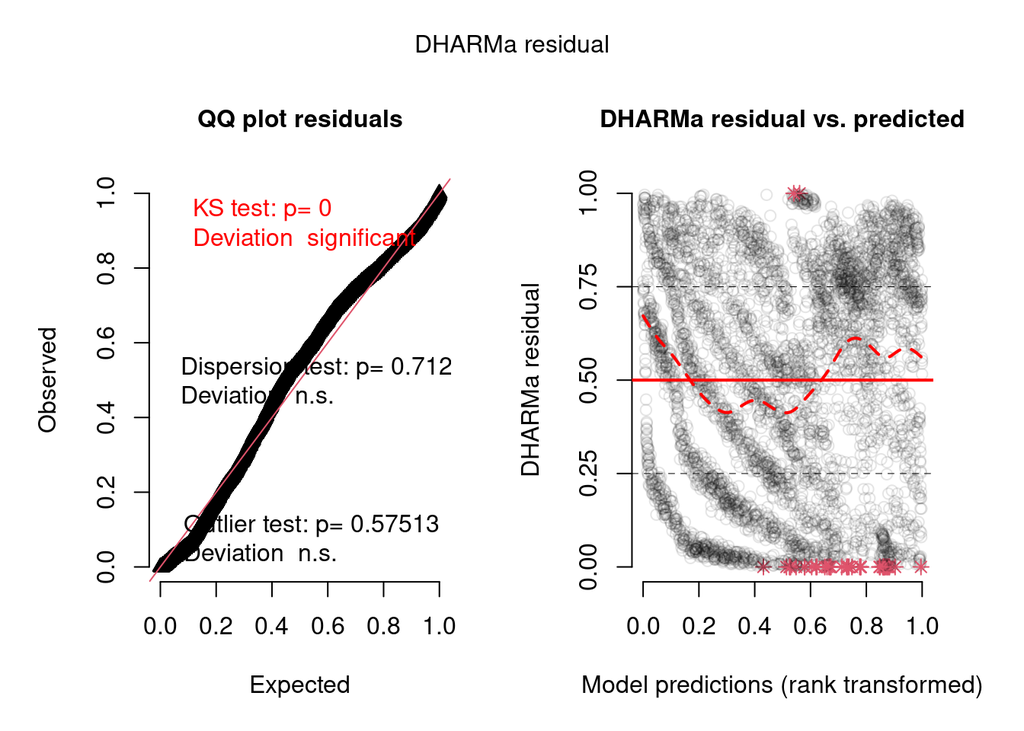

```
# A tibble: 7 × 3
  term                                                               edf p.value
  <chr>                                                            <dbl>   <dbl>
1 s(delta.resid):interaction(Predicted.class.levelup, root_type, …  2.43 3.24e-5
2 s(delta.resid):interaction(Predicted.class.levelup, root_type, …  4.12 0
3 s(delta.resid):interaction(Predicted.class.levelup, root_type, …  2.73 6.50e-6
4 s(delta.resid):interaction(Predicted.class.levelup, root_type, …  5.20 9.00e-3
5 s(delta.resid):interaction(Predicted.class.levelup, root_type, …  4.41 4.47e-3
6 s(scanner)                                                        6.93 0
7 s(period)                                                         5.98 0
```

Statistical comparison between Mechanistic and Functional models

| Model | Adj. R² | Deviance | AIC | BIC | df | N Obs. |
| --- | --- | --- | --- | --- | --- | --- |
| Mechanistic | 0.008 | 7681.083 | 16264.37 | 16371.35 | 13.025 | 4954 |
| Functional | 0.543 | 499.904 | 10667.34 | 10931.46 | 35.793 | 4954 |

Demographic processes (population density) do not explain spatial selection patterns ($R^2 \approx 0.008$). Conversely, biological selection significantly influences demographic processes ($R^2 \approx 0.54$).

Surprisingly, our results initially appeared to contradict the “functional oasis” hypothesis. Instantaneous abundance was lower where selection was most intense, suggesting that the local carrying capacity is not influenced by the ability to exploit the rhizosphere, but rather the ability not to exploit it.

#### **Could there be a phase shift between the selection behaviour of growing roots and demographic success?**

We introduced temporal lags (Lag 1 and Lag 2) into our GAMs to determine if there is a phase shift between selection behavior and demographic success.

Model :

`gam (abundance ~ Predicted.class.levelup + root_type + s(lag1_delta_resid, by = interaction(Predicted.class.levelup, root_type, drop = TRUE), k=10) + s(lag2_delta_resid, by = interaction(Predicted.class.levelup, root_type, drop = TRUE), k=10) + s(delta.resid, by = interaction(Predicted.class.levelup, root_type, drop = TRUE), k=10) + s(scanner, bs="re")+ s(period, bs="re"), Gamma(link = "log"), data = data_growth, method = "REML", select = TRUE)`

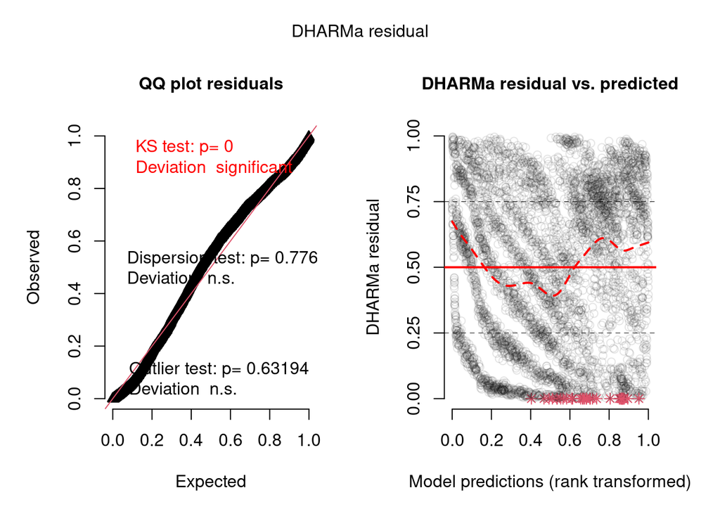

```
# A tibble: 14 × 3
   term                                                              edf p.value
   <chr>                                                           <dbl>   <dbl>
 1 s(lag1_delta_resid):interaction(Predicted.class.levelup, root_…  3.98 1.51e-4
 2 s(lag1_delta_resid):interaction(Predicted.class.levelup, root_…  2.09 9.15e-3
 3 s(lag1_delta_resid):interaction(Predicted.class.levelup, root_…  4.56 8.99e-4
 4 s(lag1_delta_resid):interaction(Predicted.class.levelup, root_…  3.44 3.96e-2
 5 s(lag2_delta_resid):interaction(Predicted.class.levelup, root_…  3.62 6.29e-3
 6 s(lag2_delta_resid):interaction(Predicted.class.levelup, root_…  5.28 1.74e-5
 7 s(lag2_delta_resid):interaction(Predicted.class.levelup, root_…  3.87 1.79e-2
 8 s(delta.resid):interaction(Predicted.class.levelup, root_type,…  2.20 1.42e-3
 9 s(delta.resid):interaction(Predicted.class.levelup, root_type,…  3.54 1.84e-6
10 s(delta.resid):interaction(Predicted.class.levelup, root_type,…  2.24 6.73e-3
11 s(delta.resid):interaction(Predicted.class.levelup, root_type,…  4.58 3.00e-4
12 s(delta.resid):interaction(Predicted.class.levelup, root_type,…  3.94 1.93e-3
13 s(scanner)                                                       6.92 0
14 s(period)                                                        5.98 0
```

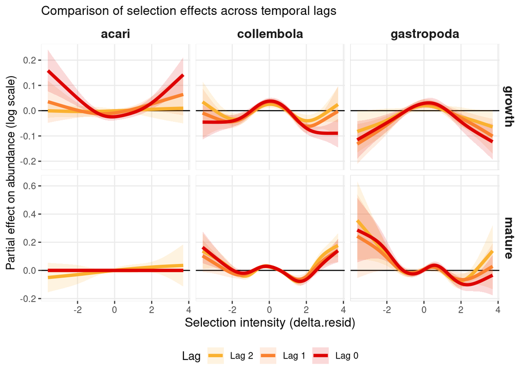